# Risk Factor Analysis

## Outcome Variable

**Outcome Variable:** ever_stunted

## Predictor Variables

**Intervention Variable:** exclfeed6

**Adjustment Set:**

- arm
- W_mage
- meducyrs
- feducyrs
- hhwealth_quart
- hfoodsec
- W_mhtcm
- vagbrth
- W_gagebrth
- W_birthwt
- W_birthlen
- W_nrooms
- W_nchldlt5
- month
- brthmon
- W_parity
- impfloor
- impsan
- safeh20
- delta_W_mage
- delta_meducyrs
- delta_feducyrs
- delta_hhwealth_quart
- delta_hfoodsec
- delta_W_mhtcm
- delta_vagbrth
- delta_W_gagebrth
- delta_W_birthwt
- delta_W_birthlen
- delta_W_nrooms
- delta_W_nchldlt5
- delta_month
- delta_brthmon
- delta_W_parity
- delta_impfloor
- delta_impsan
- delta_safeh20

## Stratifying Variables

The analysis was stratified on these variable(s):

- agecat
- studyid
- country

## Data Summary

| agecat | studyid | country | exclfeed6 | ever_stunted | n_cell | n |
| --- | --- | --- | --- | --- | --- | --- |
| 0-24 months (no birth st.) | ki0047075b-MAL-ED | BANGLADESH | 1 | 0 | 20 | 198 |
| 0-24 months (no birth st.) | ki0047075b-MAL-ED | BANGLADESH | 1 | 1 | 28 | 198 |
| 0-24 months (no birth st.) | ki0047075b-MAL-ED | BANGLADESH | 0 | 0 | 71 | 198 |
| 0-24 months (no birth st.) | ki0047075b-MAL-ED | BANGLADESH | 0 | 1 | 79 | 198 |
| 0-24 months (no birth st.) | ki0047075b-MAL-ED | BRAZIL | 1 | 0 | 13 | 191 |
| 0-24 months (no birth st.) | ki0047075b-MAL-ED | BRAZIL | 1 | 1 | 1 | 191 |
| 0-24 months (no birth st.) | ki0047075b-MAL-ED | BRAZIL | 0 | 0 | 150 | 191 |
| 0-24 months (no birth st.) | ki0047075b-MAL-ED | BRAZIL | 0 | 1 | 27 | 191 |
| 0-24 months (no birth st.) | ki0047075b-MAL-ED | INDIA | 1 | 0 | 2 | 194 |
| 0-24 months (no birth st.) | ki0047075b-MAL-ED | INDIA | 1 | 1 | 1 | 194 |
| 0-24 months (no birth st.) | ki0047075b-MAL-ED | INDIA | 0 | 0 | 86 | 194 |
| 0-24 months (no birth st.) | ki0047075b-MAL-ED | INDIA | 0 | 1 | 105 | 194 |
| 0-24 months (no birth st.) | ki0047075b-MAL-ED | NEPAL | 1 | 0 | 11 | 208 |
| 0-24 months (no birth st.) | ki0047075b-MAL-ED | NEPAL | 1 | 1 | 4 | 208 |
| 0-24 months (no birth st.) | ki0047075b-MAL-ED | NEPAL | 0 | 0 | 143 | 208 |
| 0-24 months (no birth st.) | ki0047075b-MAL-ED | NEPAL | 0 | 1 | 50 | 208 |
| 0-24 months (no birth st.) | ki0047075b-MAL-ED | PERU | 1 | 0 | 2 | 238 |
| 0-24 months (no birth st.) | ki0047075b-MAL-ED | PERU | 1 | 1 | 7 | 238 |
| 0-24 months (no birth st.) | ki0047075b-MAL-ED | PERU | 0 | 0 | 90 | 238 |
| 0-24 months (no birth st.) | ki0047075b-MAL-ED | PERU | 0 | 1 | 139 | 238 |
| 0-24 months (no birth st.) | ki0047075b-MAL-ED | SOUTH AFRICA | 1 | 0 | 0 | 222 |
| 0-24 months (no birth st.) | ki0047075b-MAL-ED | SOUTH AFRICA | 1 | 1 | 0 | 222 |
| 0-24 months (no birth st.) | ki0047075b-MAL-ED | SOUTH AFRICA | 0 | 0 | 96 | 222 |
| 0-24 months (no birth st.) | ki0047075b-MAL-ED | SOUTH AFRICA | 0 | 1 | 126 | 222 |
| 0-24 months (no birth st.) | ki0047075b-MAL-ED | TANZANIA, UNITED REPUBLIC OF | 1 | 0 | 0 | 210 |
| 0-24 months (no birth st.) | ki0047075b-MAL-ED | TANZANIA, UNITED REPUBLIC OF | 1 | 1 | 1 | 210 |
| 0-24 months (no birth st.) | ki0047075b-MAL-ED | TANZANIA, UNITED REPUBLIC OF | 0 | 0 | 35 | 210 |
| 0-24 months (no birth st.) | ki0047075b-MAL-ED | TANZANIA, UNITED REPUBLIC OF | 0 | 1 | 174 | 210 |
| 0-24 months (no birth st.) | ki1000108-CMC-V-BCS-2002 | INDIA | 1 | 0 | 1 | 14 |
| 0-24 months (no birth st.) | ki1000108-CMC-V-BCS-2002 | INDIA | 1 | 1 | 13 | 14 |

[output cut: 186 more lines]

The following strata were considered:

- agecat: 0-24 months (no birth st.), studyid: ki0047075b-MAL-ED, country: BANGLADESH
- agecat: 0-24 months (no birth st.), studyid: ki0047075b-MAL-ED, country: BRAZIL
- agecat: 0-24 months (no birth st.), studyid: ki0047075b-MAL-ED, country: INDIA
- agecat: 0-24 months (no birth st.), studyid: ki0047075b-MAL-ED, country: NEPAL
- agecat: 0-24 months (no birth st.), studyid: ki0047075b-MAL-ED, country: PERU
- agecat: 0-24 months (no birth st.), studyid: ki0047075b-MAL-ED, country: SOUTH AFRICA
- agecat: 0-24 months (no birth st.), studyid: ki0047075b-MAL-ED, country: TANZANIA, UNITED REPUBLIC OF
- agecat: 0-24 months (no birth st.), studyid: ki1000108-CMC-V-BCS-2002, country: INDIA
- agecat: 0-24 months (no birth st.), studyid: ki1000108-IRC, country: INDIA
- agecat: 0-24 months (no birth st.), studyid: ki1000109-EE, country: PAKISTAN
- agecat: 0-24 months (no birth st.), studyid: ki1000304b-SAS-CompFeed, country: INDIA
- agecat: 0-24 months (no birth st.), studyid: ki1000304b-SAS-FoodSuppl, country: INDIA
- agecat: 0-24 months (no birth st.), studyid: ki1017093b-PROVIDE, country: BANGLADESH
- agecat: 0-24 months (no birth st.), studyid: ki1101329-Keneba, country: GAMBIA
- agecat: 0-24 months (no birth st.), studyid: ki1113344-GMS-Nepal, country: NEPAL
- agecat: 0-24 months (no birth st.), studyid: ki1148112-LCNI-5, country: MALAWI
- agecat: 0-24 months (no birth st.), studyid: kiGH5241-JiVitA-3, country: BANGLADESH
- agecat: 0-24 months (no birth st.), studyid: kiGH5241-JiVitA-4, country: BANGLADESH
- agecat: 0-6 months (no birth st.), studyid: ki0047075b-MAL-ED, country: BANGLADESH
- agecat: 0-6 months (no birth st.), studyid: ki0047075b-MAL-ED, country: BRAZIL
- agecat: 0-6 months (no birth st.), studyid: ki0047075b-MAL-ED, country: INDIA
- agecat: 0-6 months (no birth st.), studyid: ki0047075b-MAL-ED, country: NEPAL
- agecat: 0-6 months (no birth st.), studyid: ki0047075b-MAL-ED, country: PERU
- agecat: 0-6 months (no birth st.), studyid: ki0047075b-MAL-ED, country: SOUTH AFRICA
- agecat: 0-6 months (no birth st.), studyid: ki0047075b-MAL-ED, country: TANZANIA, UNITED REPUBLIC OF
- agecat: 0-6 months (no birth st.), studyid: ki1000108-CMC-V-BCS-2002, country: INDIA
- agecat: 0-6 months (no birth st.), studyid: ki1000108-IRC, country: INDIA
- agecat: 0-6 months (no birth st.), studyid: ki1000109-EE, country: PAKISTAN
- agecat: 0-6 months (no birth st.), studyid: ki1000304b-SAS-CompFeed, country: INDIA
- agecat: 0-6 months (no birth st.), studyid: ki1000304b-SAS-FoodSuppl, country: INDIA
- agecat: 0-6 months (no birth st.), studyid: ki1017093b-PROVIDE, country: BANGLADESH
- agecat: 0-6 months (no birth st.), studyid: ki1101329-Keneba, country: GAMBIA
- agecat: 0-6 months (no birth st.), studyid: ki1113344-GMS-Nepal, country: NEPAL
- agecat: 0-6 months (no birth st.), studyid: ki1148112-LCNI-5, country: MALAWI
- agecat: 0-6 months (no birth st.), studyid: kiGH5241-JiVitA-3, country: BANGLADESH
- agecat: 0-6 months (no birth st.), studyid: kiGH5241-JiVitA-4, country: BANGLADESH
- agecat: 6-24 months, studyid: ki0047075b-MAL-ED, country: BANGLADESH
- agecat: 6-24 months, studyid: ki0047075b-MAL-ED, country: BRAZIL
- agecat: 6-24 months, studyid: ki0047075b-MAL-ED, country: INDIA
- agecat: 6-24 months, studyid: ki0047075b-MAL-ED, country: NEPAL
- agecat: 6-24 months, studyid: ki0047075b-MAL-ED, country: PERU
- agecat: 6-24 months, studyid: ki0047075b-MAL-ED, country: SOUTH AFRICA
- agecat: 6-24 months, studyid: ki0047075b-MAL-ED, country: TANZANIA, UNITED REPUBLIC OF
- agecat: 6-24 months, studyid: ki1000108-CMC-V-BCS-2002, country: INDIA
- agecat: 6-24 months, studyid: ki1000108-IRC, country: INDIA
- agecat: 6-24 months, studyid: ki1000109-EE, country: PAKISTAN
- agecat: 6-24 months, studyid: ki1000304b-SAS-CompFeed, country: INDIA
- agecat: 6-24 months, studyid: ki1000304b-SAS-FoodSuppl, country: INDIA
- agecat: 6-24 months, studyid: ki1017093b-PROVIDE, country: BANGLADESH
- agecat: 6-24 months, studyid: ki1101329-Keneba, country: GAMBIA
- agecat: 6-24 months, studyid: ki1113344-GMS-Nepal, country: NEPAL
- agecat: 6-24 months, studyid: ki1148112-LCNI-5, country: MALAWI
- agecat: 6-24 months, studyid: kiGH5241-JiVitA-3, country: BANGLADESH
- agecat: 6-24 months, studyid: kiGH5241-JiVitA-4, country: BANGLADESH

### Dropped Strata

Some strata were dropped due to rare outcomes:

- agecat: 0-24 months (no birth st.), studyid: ki0047075b-MAL-ED, country: BRAZIL
- agecat: 0-24 months (no birth st.), studyid: ki0047075b-MAL-ED, country: INDIA
- agecat: 0-24 months (no birth st.), studyid: ki0047075b-MAL-ED, country: NEPAL
- agecat: 0-24 months (no birth st.), studyid: ki0047075b-MAL-ED, country: PERU
- agecat: 0-24 months (no birth st.), studyid: ki0047075b-MAL-ED, country: SOUTH AFRICA
- agecat: 0-24 months (no birth st.), studyid: ki0047075b-MAL-ED, country: TANZANIA, UNITED REPUBLIC OF
- agecat: 0-24 months (no birth st.), studyid: ki1000108-CMC-V-BCS-2002, country: INDIA
- agecat: 0-24 months (no birth st.), studyid: ki1000108-IRC, country: INDIA
- agecat: 0-24 months (no birth st.), studyid: ki1000304b-SAS-FoodSuppl, country: INDIA
- agecat: 0-6 months (no birth st.), studyid: ki0047075b-MAL-ED, country: BRAZIL
- agecat: 0-6 months (no birth st.), studyid: ki0047075b-MAL-ED, country: INDIA
- agecat: 0-6 months (no birth st.), studyid: ki0047075b-MAL-ED, country: NEPAL
- agecat: 0-6 months (no birth st.), studyid: ki0047075b-MAL-ED, country: PERU
- agecat: 0-6 months (no birth st.), studyid: ki0047075b-MAL-ED, country: SOUTH AFRICA
- agecat: 0-6 months (no birth st.), studyid: ki0047075b-MAL-ED, country: TANZANIA, UNITED REPUBLIC OF
- agecat: 0-6 months (no birth st.), studyid: ki1000108-CMC-V-BCS-2002, country: INDIA
- agecat: 0-6 months (no birth st.), studyid: ki1000108-IRC, country: INDIA
- agecat: 0-6 months (no birth st.), studyid: ki1000304b-SAS-FoodSuppl, country: INDIA
- agecat: 0-6 months (no birth st.), studyid: ki1148112-LCNI-5, country: MALAWI
- agecat: 6-24 months, studyid: ki0047075b-MAL-ED, country: BRAZIL
- agecat: 6-24 months, studyid: ki0047075b-MAL-ED, country: INDIA
- agecat: 6-24 months, studyid: ki0047075b-MAL-ED, country: NEPAL
- agecat: 6-24 months, studyid: ki0047075b-MAL-ED, country: PERU
- agecat: 6-24 months, studyid: ki0047075b-MAL-ED, country: SOUTH AFRICA
- agecat: 6-24 months, studyid: ki0047075b-MAL-ED, country: TANZANIA, UNITED REPUBLIC OF
- agecat: 6-24 months, studyid: ki1000108-CMC-V-BCS-2002, country: INDIA
- agecat: 6-24 months, studyid: ki1000108-IRC, country: INDIA
- agecat: 6-24 months, studyid: ki1000304b-SAS-CompFeed, country: INDIA
- agecat: 6-24 months, studyid: ki1000304b-SAS-FoodSuppl, country: INDIA

## Methods Detail

We’re interested in the causal parameters $E[Y_a]$ for all values of $a \in \mathcal{A}$. These parameters represent the mean outcome if, possibly contrary to fact, we intervened to set all units to have $A=a$. Under the randomization and positivity assumptions, these are identified by the statistical parameters $\psi_a=E_W[E_{Y|A,W}(Y|A=a,W)]$. In addition, we’re interested in the mean of $Y$, $E[Y]$ under no intervention (the observed mean). We will estimate these parameters by using SuperLearner to fit the relevant likelihood factors – $E_{Y|A,W}(Y|A=a,W)$ and $p(A=a|W)$, and then updating our likelihood fit using a joint TMLE.

For unadjusted analyses ($W=\{\}$), initial likelihoods were estimated using Lrnr_glm to estimate the simple $E(Y|A)$ and Lrnr_mean to estimate $p(A)$. For adjusted analyses, a small library containing Lrnr_glmnet, Lrnr_xgboost, and Lrnr_mean was used.

Having estimated these parameters, we will then use the delta method to estimate relative risks and attributable risks relative to a prespecified baseline level of $A$.

# Results Detail

## Results Plots

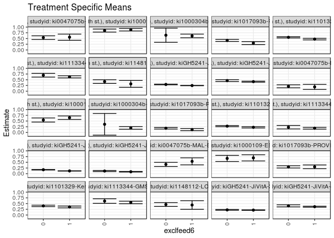

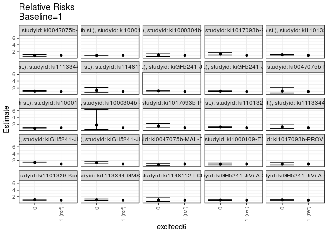

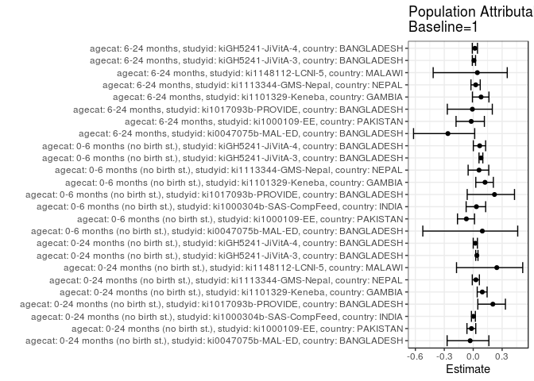

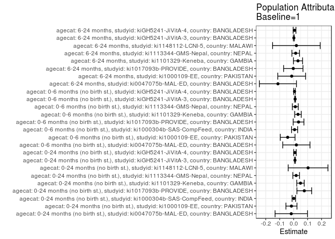

## Results Table

### Parameter: TSM

| agecat | studyid | country | intervention_level | baseline_level | estimate | ci_lower | ci_upper |
| --- | --- | --- | --- | --- | --- | --- | --- |
| 0-24 months (no birth st.) | ki0047075b-MAL-ED | BANGLADESH | 1 | NA | 0.5575160 | 0.4212591 | 0.6937730 |
| 0-24 months (no birth st.) | ki0047075b-MAL-ED | BANGLADESH | 0 | NA | 0.5370259 | 0.4583838 | 0.6156680 |
| 0-24 months (no birth st.) | ki1000109-EE | PAKISTAN | 1 | NA | 0.8832921 | 0.8283143 | 0.9382700 |
| 0-24 months (no birth st.) | ki1000109-EE | PAKISTAN | 0 | NA | 0.8484061 | 0.7823104 | 0.9145018 |
| 0-24 months (no birth st.) | ki1000304b-SAS-CompFeed | INDIA | 1 | NA | 0.6121795 | 0.5306906 | 0.6936683 |
| 0-24 months (no birth st.) | ki1000304b-SAS-CompFeed | INDIA | 0 | NA | 0.6428571 | 0.3329177 | 0.9527966 |
| 0-24 months (no birth st.) | ki1017093b-PROVIDE | BANGLADESH | 1 | NA | 0.2989265 | 0.2344477 | 0.3634052 |
| 0-24 months (no birth st.) | ki1017093b-PROVIDE | BANGLADESH | 0 | NA | 0.4157458 | 0.3705316 | 0.4609599 |
| 0-24 months (no birth st.) | ki1101329-Keneba | GAMBIA | 1 | NA | 0.4728086 | 0.4383640 | 0.5072532 |
| 0-24 months (no birth st.) | ki1101329-Keneba | GAMBIA | 0 | NA | 0.5508653 | 0.5241166 | 0.5776140 |
| 0-24 months (no birth st.) | ki1113344-GMS-Nepal | NEPAL | 1 | NA | 0.6267720 | 0.5778447 | 0.6756993 |
| 0-24 months (no birth st.) | ki1113344-GMS-Nepal | NEPAL | 0 | NA | 0.6987326 | 0.6170041 | 0.7804612 |
| 0-24 months (no birth st.) | ki1148112-LCNI-5 | MALAWI | 1 | NA | 0.3194161 | 0.1700193 | 0.4688129 |
| 0-24 months (no birth st.) | ki1148112-LCNI-5 | MALAWI | 0 | NA | 0.4197726 | 0.3391963 | 0.5003489 |
| 0-24 months (no birth st.) | kiGH5241-JiVitA-3 | BANGLADESH | 1 | NA | 0.2471444 | 0.2386936 | 0.2555951 |
| 0-24 months (no birth st.) | kiGH5241-JiVitA-3 | BANGLADESH | 0 | NA | 0.2944854 | 0.2795011 | 0.3094697 |
| 0-24 months (no birth st.) | kiGH5241-JiVitA-4 | BANGLADESH | 1 | NA | 0.4178905 | 0.3957969 | 0.4399840 |
| 0-24 months (no birth st.) | kiGH5241-JiVitA-4 | BANGLADESH | 0 | NA | 0.4637682 | 0.4220344 | 0.5055021 |
| 0-6 months (no birth st.) | ki0047075b-MAL-ED | BANGLADESH | 1 | NA | 0.1875000 | 0.0768021 | 0.2981979 |
| 0-6 months (no birth st.) | ki0047075b-MAL-ED | BANGLADESH | 0 | NA | 0.2133333 | 0.1476089 | 0.2790577 |
| 0-6 months (no birth st.) | ki1000109-EE | PAKISTAN | 1 | NA | 0.6452717 | 0.5678277 | 0.7227158 |
| 0-6 months (no birth st.) | ki1000109-EE | PAKISTAN | 0 | NA | 0.5446077 | 0.4544424 | 0.6347730 |
| 0-6 months (no birth st.) | ki1000304b-SAS-CompFeed | INDIA | 1 | NA | 0.1987179 | 0.1419130 | 0.2555229 |
| 0-6 months (no birth st.) | ki1000304b-SAS-CompFeed | INDIA | 0 | NA | 0.3571429 | -0.1170496 | 0.8313354 |
| 0-6 months (no birth st.) | ki1017093b-PROVIDE | BANGLADESH | 1 | NA | 0.1241565 | 0.0781844 | 0.1701286 |
| 0-6 months (no birth st.) | ki1017093b-PROVIDE | BANGLADESH | 0 | NA | 0.1834855 | 0.1482008 | 0.2187701 |
| 0-6 months (no birth st.) | ki1101329-Keneba | GAMBIA | 1 | NA | 0.2246828 | 0.1955540 | 0.2538116 |
| 0-6 months (no birth st.) | ki1101329-Keneba | GAMBIA | 0 | NA | 0.2758775 | 0.2517449 | 0.3000101 |
| 0-6 months (no birth st.) | ki1113344-GMS-Nepal | NEPAL | 1 | NA | 0.1856805 | 0.1463313 | 0.2250298 |
| 0-6 months (no birth st.) | ki1113344-GMS-Nepal | NEPAL | 0 | NA | 0.2291260 | 0.1543437 | 0.3039084 |
| 0-6 months (no birth st.) | kiGH5241-JiVitA-3 | BANGLADESH | 1 | NA | 0.1225302 | 0.1164261 | 0.1286343 |
| 0-6 months (no birth st.) | kiGH5241-JiVitA-3 | BANGLADESH | 0 | NA | 0.1746323 | 0.1620842 | 0.1871804 |
| 0-6 months (no birth st.) | kiGH5241-JiVitA-4 | BANGLADESH | 1 | NA | 0.0866748 | 0.0732565 | 0.1000932 |
| 0-6 months (no birth st.) | kiGH5241-JiVitA-4 | BANGLADESH | 0 | NA | 0.1178761 | 0.0918609 | 0.1438914 |
| 6-24 months | ki0047075b-MAL-ED | BANGLADESH | 1 | NA | 0.5410977 | 0.3881636 | 0.6940317 |
| 6-24 months | ki0047075b-MAL-ED | BANGLADESH | 0 | NA | 0.4082195 | 0.3182944 | 0.4981447 |
| 6-24 months | ki1000109-EE | PAKISTAN | 1 | NA | 0.6944383 | 0.5601197 | 0.8287569 |
| 6-24 months | ki1000109-EE | PAKISTAN | 0 | NA | 0.6696948 | 0.5371281 | 0.8022615 |
| 6-24 months | ki1017093b-PROVIDE | BANGLADESH | 1 | NA | 0.3023561 | 0.2202461 | 0.3844661 |
| 6-24 months | ki1017093b-PROVIDE | BANGLADESH | 0 | NA | 0.2996624 | 0.2516067 | 0.3477181 |
| 6-24 months | ki1101329-Keneba | GAMBIA | 1 | NA | 0.3512121 | 0.3103719 | 0.3920522 |
| 6-24 months | ki1101329-Keneba | GAMBIA | 0 | NA | 0.3986674 | 0.3669337 | 0.4304011 |
| 6-24 months | ki1113344-GMS-Nepal | NEPAL | 1 | NA | 0.5496375 | 0.4934283 | 0.6058468 |
| 6-24 months | ki1113344-GMS-Nepal | NEPAL | 0 | NA | 0.6098681 | 0.5093284 | 0.7104078 |
| 6-24 months | ki1148112-LCNI-5 | MALAWI | 1 | NA | 0.4371276 | 0.2488202 | 0.6254351 |
| 6-24 months | ki1148112-LCNI-5 | MALAWI | 0 | NA | 0.4590385 | 0.3745668 | 0.5435102 |
| 6-24 months | kiGH5241-JiVitA-3 | BANGLADESH | 1 | NA | 0.2143467 | 0.2041830 | 0.2245104 |
| 6-24 months | kiGH5241-JiVitA-3 | BANGLADESH | 0 | NA | 0.2235306 | 0.2043261 | 0.2427351 |
| 6-24 months | kiGH5241-JiVitA-4 | BANGLADESH | 1 | NA | 0.3634250 | 0.3412917 | 0.3855583 |
| 6-24 months | kiGH5241-JiVitA-4 | BANGLADESH | 0 | NA | 0.3992545 | 0.3529336 | 0.4455754 |

### Parameter: E(Y)

| agecat | studyid | country | intervention_level | baseline_level | estimate | ci_lower | ci_upper |
| --- | --- | --- | --- | --- | --- | --- | --- |
| 0-24 months (no birth st.) | ki0047075b-MAL-ED | BANGLADESH | NA | NA | 0.5404040 | 0.4708116 | 0.6099965 |
| 0-24 months (no birth st.) | ki1000109-EE | PAKISTAN | NA | NA | 0.8674699 | 0.8252704 | 0.9096693 |
| 0-24 months (no birth st.) | ki1000304b-SAS-CompFeed | INDIA | NA | NA | 0.6134969 | 0.5286303 | 0.6983636 |
| 0-24 months (no birth st.) | ki1017093b-PROVIDE | BANGLADESH | NA | NA | 0.3753943 | 0.3376725 | 0.4131162 |
| 0-24 months (no birth st.) | ki1101329-Keneba | GAMBIA | NA | NA | 0.5219970 | 0.5002246 | 0.5437695 |
| 0-24 months (no birth st.) | ki1113344-GMS-Nepal | NEPAL | NA | NA | 0.6447106 | 0.6027601 | 0.6866610 |
| 0-24 months (no birth st.) | ki1148112-LCNI-5 | MALAWI | NA | NA | 0.4228571 | 0.3494545 | 0.4962598 |
| 0-24 months (no birth st.) | kiGH5241-JiVitA-3 | BANGLADESH | NA | NA | 0.2568529 | 0.2489241 | 0.2647817 |
| 0-24 months (no birth st.) | kiGH5241-JiVitA-4 | BANGLADESH | NA | NA | 0.4273377 | 0.4072583 | 0.4474171 |
| 0-6 months (no birth st.) | ki0047075b-MAL-ED | BANGLADESH | NA | NA | 0.2070707 | 0.1504870 | 0.2636544 |
| 0-6 months (no birth st.) | ki1000109-EE | PAKISTAN | NA | NA | 0.6024096 | 0.5415000 | 0.6633193 |
| 0-6 months (no birth st.) | ki1000304b-SAS-CompFeed | INDIA | NA | NA | 0.2055215 | 0.1385538 | 0.2724891 |
| 0-6 months (no birth st.) | ki1017093b-PROVIDE | BANGLADESH | NA | NA | 0.1593060 | 0.1307970 | 0.1878149 |
| 0-6 months (no birth st.) | ki1101329-Keneba | GAMBIA | NA | NA | 0.2560554 | 0.2370317 | 0.2750791 |
| 0-6 months (no birth st.) | ki1113344-GMS-Nepal | NEPAL | NA | NA | 0.1976048 | 0.1627023 | 0.2325072 |
| 0-6 months (no birth st.) | kiGH5241-JiVitA-3 | BANGLADESH | NA | NA | 0.1331973 | 0.1275046 | 0.1388899 |
| 0-6 months (no birth st.) | kiGH5241-JiVitA-4 | BANGLADESH | NA | NA | 0.0929124 | 0.0809295 | 0.1048954 |
| 6-24 months | ki0047075b-MAL-ED | BANGLADESH | NA | NA | 0.4285714 | 0.3501572 | 0.5069857 |
| 6-24 months | ki1000109-EE | PAKISTAN | NA | NA | 0.6804124 | 0.5871313 | 0.7736934 |
| 6-24 months | ki1017093b-PROVIDE | BANGLADESH | NA | NA | 0.2997812 | 0.2577294 | 0.3418330 |
| 6-24 months | ki1101329-Keneba | GAMBIA | NA | NA | 0.3823738 | 0.3569722 | 0.4077755 |
| 6-24 months | ki1113344-GMS-Nepal | NEPAL | NA | NA | 0.5642317 | 0.5153938 | 0.6130696 |
| 6-24 months | ki1148112-LCNI-5 | MALAWI | NA | NA | 0.4567901 | 0.3798457 | 0.5337346 |
| 6-24 months | kiGH5241-JiVitA-3 | BANGLADESH | NA | NA | 0.2160008 | 0.2065441 | 0.2254575 |
| 6-24 months | kiGH5241-JiVitA-4 | BANGLADESH | NA | NA | 0.3699441 | 0.3495174 | 0.3903708 |

### Parameter: RR

| agecat | studyid | country | intervention_level | baseline_level | estimate | ci_lower | ci_upper |
| --- | --- | --- | --- | --- | --- | --- | --- |
| 0-24 months (no birth st.) | ki0047075b-MAL-ED | BANGLADESH | 1 | 1 | 1.0000000 | 1.0000000 | 1.000000 |
| 0-24 months (no birth st.) | ki0047075b-MAL-ED | BANGLADESH | 0 | 1 | 0.9632474 | 0.7311865 | 1.268959 |
| 0-24 months (no birth st.) | ki1000109-EE | PAKISTAN | 1 | 1 | 1.0000000 | 1.0000000 | 1.000000 |
| 0-24 months (no birth st.) | ki1000109-EE | PAKISTAN | 0 | 1 | 0.9605045 | 0.8691021 | 1.061519 |
| 0-24 months (no birth st.) | ki1000304b-SAS-CompFeed | INDIA | 1 | 1 | 1.0000000 | 1.0000000 | 1.000000 |
| 0-24 months (no birth st.) | ki1000304b-SAS-CompFeed | INDIA | 0 | 1 | 1.0501122 | 0.6736522 | 1.636951 |
| 0-24 months (no birth st.) | ki1017093b-PROVIDE | BANGLADESH | 1 | 1 | 1.0000000 | 1.0000000 | 1.000000 |
| 0-24 months (no birth st.) | ki1017093b-PROVIDE | BANGLADESH | 0 | 1 | 1.3907962 | 1.0984446 | 1.760957 |
| 0-24 months (no birth st.) | ki1101329-Keneba | GAMBIA | 1 | 1 | 1.0000000 | 1.0000000 | 1.000000 |
| 0-24 months (no birth st.) | ki1101329-Keneba | GAMBIA | 0 | 1 | 1.1650915 | 1.0703342 | 1.268238 |
| 0-24 months (no birth st.) | ki1113344-GMS-Nepal | NEPAL | 1 | 1 | 1.0000000 | 1.0000000 | 1.000000 |
| 0-24 months (no birth st.) | ki1113344-GMS-Nepal | NEPAL | 0 | 1 | 1.1148115 | 0.9683678 | 1.283402 |
| 0-24 months (no birth st.) | ki1148112-LCNI-5 | MALAWI | 1 | 1 | 1.0000000 | 1.0000000 | 1.000000 |
| 0-24 months (no birth st.) | ki1148112-LCNI-5 | MALAWI | 0 | 1 | 1.3141872 | 0.7898044 | 2.186729 |
| 0-24 months (no birth st.) | kiGH5241-JiVitA-3 | BANGLADESH | 1 | 1 | 1.0000000 | 1.0000000 | 1.000000 |
| 0-24 months (no birth st.) | kiGH5241-JiVitA-3 | BANGLADESH | 0 | 1 | 1.1915521 | 1.1281353 | 1.258534 |
| 0-24 months (no birth st.) | kiGH5241-JiVitA-4 | BANGLADESH | 1 | 1 | 1.0000000 | 1.0000000 | 1.000000 |
| 0-24 months (no birth st.) | kiGH5241-JiVitA-4 | BANGLADESH | 0 | 1 | 1.1097842 | 1.0030337 | 1.227896 |
| 0-6 months (no birth st.) | ki0047075b-MAL-ED | BANGLADESH | 1 | 1 | 1.0000000 | 1.0000000 | 1.000000 |
| 0-6 months (no birth st.) | ki0047075b-MAL-ED | BANGLADESH | 0 | 1 | 1.1377778 | 0.5845801 | 2.214475 |
| 0-6 months (no birth st.) | ki1000109-EE | PAKISTAN | 1 | 1 | 1.0000000 | 1.0000000 | 1.000000 |
| 0-6 months (no birth st.) | ki1000109-EE | PAKISTAN | 0 | 1 | 0.8439974 | 0.6933352 | 1.027399 |
| 0-6 months (no birth st.) | ki1000304b-SAS-CompFeed | INDIA | 1 | 1 | 1.0000000 | 1.0000000 | 1.000000 |
| 0-6 months (no birth st.) | ki1000304b-SAS-CompFeed | INDIA | 0 | 1 | 1.7972350 | 0.5064696 | 6.377587 |
| 0-6 months (no birth st.) | ki1017093b-PROVIDE | BANGLADESH | 1 | 1 | 1.0000000 | 1.0000000 | 1.000000 |
| 0-6 months (no birth st.) | ki1017093b-PROVIDE | BANGLADESH | 0 | 1 | 1.4778563 | 0.9853791 | 2.216466 |
| 0-6 months (no birth st.) | ki1101329-Keneba | GAMBIA | 1 | 1 | 1.0000000 | 1.0000000 | 1.000000 |
| 0-6 months (no birth st.) | ki1101329-Keneba | GAMBIA | 0 | 1 | 1.2278531 | 1.0542967 | 1.429980 |
| 0-6 months (no birth st.) | ki1113344-GMS-Nepal | NEPAL | 1 | 1 | 1.0000000 | 1.0000000 | 1.000000 |
| 0-6 months (no birth st.) | ki1113344-GMS-Nepal | NEPAL | 0 | 1 | 1.2339799 | 0.8357253 | 1.822018 |
| 0-6 months (no birth st.) | kiGH5241-JiVitA-3 | BANGLADESH | 1 | 1 | 1.0000000 | 1.0000000 | 1.000000 |
| 0-6 months (no birth st.) | kiGH5241-JiVitA-3 | BANGLADESH | 0 | 1 | 1.4252181 | 1.3129989 | 1.547028 |
| 0-6 months (no birth st.) | kiGH5241-JiVitA-4 | BANGLADESH | 1 | 1 | 1.0000000 | 1.0000000 | 1.000000 |
| 0-6 months (no birth st.) | kiGH5241-JiVitA-4 | BANGLADESH | 0 | 1 | 1.3599809 | 1.0404742 | 1.777601 |
| 6-24 months | ki0047075b-MAL-ED | BANGLADESH | 1 | 1 | 1.0000000 | 1.0000000 | 1.000000 |
| 6-24 months | ki0047075b-MAL-ED | BANGLADESH | 0 | 1 | 0.7544285 | 0.5289942 | 1.075933 |
| 6-24 months | ki1000109-EE | PAKISTAN | 1 | 1 | 1.0000000 | 1.0000000 | 1.000000 |
| 6-24 months | ki1000109-EE | PAKISTAN | 0 | 1 | 0.9643690 | 0.7304710 | 1.273162 |
| 6-24 months | ki1017093b-PROVIDE | BANGLADESH | 1 | 1 | 1.0000000 | 1.0000000 | 1.000000 |
| 6-24 months | ki1017093b-PROVIDE | BANGLADESH | 0 | 1 | 0.9910909 | 0.7266264 | 1.351811 |
| 6-24 months | ki1101329-Keneba | GAMBIA | 1 | 1 | 1.0000000 | 1.0000000 | 1.000000 |
| 6-24 months | ki1101329-Keneba | GAMBIA | 0 | 1 | 1.1351187 | 0.9883755 | 1.303649 |
| 6-24 months | ki1113344-GMS-Nepal | NEPAL | 1 | 1 | 1.0000000 | 1.0000000 | 1.000000 |
| 6-24 months | ki1113344-GMS-Nepal | NEPAL | 0 | 1 | 1.1095823 | 0.9139220 | 1.347131 |
| 6-24 months | ki1148112-LCNI-5 | MALAWI | 1 | 1 | 1.0000000 | 1.0000000 | 1.000000 |
| 6-24 months | ki1148112-LCNI-5 | MALAWI | 0 | 1 | 1.0501245 | 0.6589551 | 1.673500 |
| 6-24 months | kiGH5241-JiVitA-3 | BANGLADESH | 1 | 1 | 1.0000000 | 1.0000000 | 1.000000 |
| 6-24 months | kiGH5241-JiVitA-3 | BANGLADESH | 0 | 1 | 1.0428460 | 0.9510775 | 1.143469 |
| 6-24 months | kiGH5241-JiVitA-4 | BANGLADESH | 1 | 1 | 1.0000000 | 1.0000000 | 1.000000 |
| 6-24 months | kiGH5241-JiVitA-4 | BANGLADESH | 0 | 1 | 1.0985885 | 0.9667219 | 1.248442 |

### Parameter: PAR

| agecat | studyid | country | intervention_level | baseline_level | estimate | ci_lower | ci_upper |
| --- | --- | --- | --- | --- | --- | --- | --- |
| 0-24 months (no birth st.) | ki0047075b-MAL-ED | BANGLADESH | 1 | NA | -0.0171120 | -0.1332674 | 0.0990434 |
| 0-24 months (no birth st.) | ki1000109-EE | PAKISTAN | 1 | NA | -0.0158223 | -0.0553641 | 0.0237195 |
| 0-24 months (no birth st.) | ki1000304b-SAS-CompFeed | INDIA | 1 | NA | 0.0013174 | -0.0112602 | 0.0138950 |
| 0-24 months (no birth st.) | ki1017093b-PROVIDE | BANGLADESH | 1 | NA | 0.0764679 | 0.0234373 | 0.1294984 |
| 0-24 months (no birth st.) | ki1101329-Keneba | GAMBIA | 1 | NA | 0.0491884 | 0.0225153 | 0.0758616 |
| 0-24 months (no birth st.) | ki1113344-GMS-Nepal | NEPAL | 1 | NA | 0.0179386 | -0.0057224 | 0.0415996 |
| 0-24 months (no birth st.) | ki1148112-LCNI-5 | MALAWI | 1 | NA | 0.1034410 | -0.0388936 | 0.2457756 |
| 0-24 months (no birth st.) | kiGH5241-JiVitA-3 | BANGLADESH | 1 | NA | 0.0097085 | 0.0066871 | 0.0127300 |
| 0-24 months (no birth st.) | kiGH5241-JiVitA-4 | BANGLADESH | 1 | NA | 0.0094472 | 0.0001488 | 0.0187457 |
| 0-6 months (no birth st.) | ki0047075b-MAL-ED | BANGLADESH | 1 | NA | 0.0195707 | -0.0779711 | 0.1171125 |
| 0-6 months (no birth st.) | ki1000109-EE | PAKISTAN | 1 | NA | -0.0428621 | -0.0955803 | 0.0098560 |
| 0-6 months (no birth st.) | ki1000304b-SAS-CompFeed | INDIA | 1 | NA | 0.0068035 | -0.0151879 | 0.0287949 |
| 0-6 months (no birth st.) | ki1017093b-PROVIDE | BANGLADESH | 1 | NA | 0.0351495 | -0.0032967 | 0.0735957 |
| 0-6 months (no birth st.) | ki1101329-Keneba | GAMBIA | 1 | NA | 0.0313726 | 0.0080756 | 0.0546696 |
| 0-6 months (no birth st.) | ki1113344-GMS-Nepal | NEPAL | 1 | NA | 0.0119243 | -0.0092365 | 0.0330850 |
| 0-6 months (no birth st.) | kiGH5241-JiVitA-3 | BANGLADESH | 1 | NA | 0.0106671 | 0.0080455 | 0.0132886 |
| 0-6 months (no birth st.) | kiGH5241-JiVitA-4 | BANGLADESH | 1 | NA | 0.0062376 | 0.0003853 | 0.0120899 |
| 6-24 months | ki0047075b-MAL-ED | BANGLADESH | 1 | NA | -0.1125262 | -0.2451435 | 0.0200911 |
| 6-24 months | ki1000109-EE | PAKISTAN | 1 | NA | -0.0140259 | -0.1135693 | 0.0855175 |
| 6-24 months | ki1017093b-PROVIDE | BANGLADESH | 1 | NA | -0.0025749 | -0.0719110 | 0.0667612 |
| 6-24 months | ki1101329-Keneba | GAMBIA | 1 | NA | 0.0311618 | -0.0015467 | 0.0638703 |
| 6-24 months | ki1113344-GMS-Nepal | NEPAL | 1 | NA | 0.0145942 | -0.0124223 | 0.0416107 |
| 6-24 months | ki1148112-LCNI-5 | MALAWI | 1 | NA | 0.0196625 | -0.1513246 | 0.1906496 |
| 6-24 months | kiGH5241-JiVitA-3 | BANGLADESH | 1 | NA | 0.0016540 | -0.0019592 | 0.0052672 |
| 6-24 months | kiGH5241-JiVitA-4 | BANGLADESH | 1 | NA | 0.0065191 | -0.0034182 | 0.0164564 |

### Parameter: PAF

| agecat | studyid | country | intervention_level | baseline_level | estimate | ci_lower | ci_upper |
| --- | --- | --- | --- | --- | --- | --- | --- |
| 0-24 months (no birth st.) | ki0047075b-MAL-ED | BANGLADESH | 1 | NA | -0.0316652 | -0.2706134 | 0.1623471 |
| 0-24 months (no birth st.) | ki1000109-EE | PAKISTAN | 1 | NA | -0.0182396 | -0.0649566 | 0.0264281 |
| 0-24 months (no birth st.) | ki1000304b-SAS-CompFeed | INDIA | 1 | NA | 0.0021474 | -0.0184658 | 0.0223435 |
| 0-24 months (no birth st.) | ki1017093b-PROVIDE | BANGLADESH | 1 | NA | 0.2037001 | 0.0478361 | 0.3340501 |
| 0-24 months (no birth st.) | ki1101329-Keneba | GAMBIA | 1 | NA | 0.0942313 | 0.0415011 | 0.1440605 |
| 0-24 months (no birth st.) | ki1113344-GMS-Nepal | NEPAL | 1 | NA | 0.0278242 | -0.0096940 | 0.0639483 |
| 0-24 months (no birth st.) | ki1148112-LCNI-5 | MALAWI | 1 | NA | 0.2446240 | -0.1730757 | 0.5135924 |
| 0-24 months (no birth st.) | kiGH5241-JiVitA-3 | BANGLADESH | 1 | NA | 0.0377980 | 0.0259182 | 0.0495329 |
| 0-24 months (no birth st.) | kiGH5241-JiVitA-4 | BANGLADESH | 1 | NA | 0.0221072 | 0.0000832 | 0.0436461 |
| 0-6 months (no birth st.) | ki0047075b-MAL-ED | BANGLADESH | 1 | NA | 0.0945122 | -0.5227668 | 0.4615668 |
| 0-6 months (no birth st.) | ki1000109-EE | PAKISTAN | 1 | NA | -0.0711511 | -0.1632519 | 0.0136575 |
| 0-6 months (no birth st.) | ki1000304b-SAS-CompFeed | INDIA | 1 | NA | 0.0331037 | -0.0733606 | 0.1290081 |
| 0-6 months (no birth st.) | ki1017093b-PROVIDE | BANGLADESH | 1 | NA | 0.2206414 | -0.0622818 | 0.4282121 |
| 0-6 months (no birth st.) | ki1101329-Keneba | GAMBIA | 1 | NA | 0.1225226 | 0.0267887 | 0.2088392 |
| 0-6 months (no birth st.) | ki1113344-GMS-Nepal | NEPAL | 1 | NA | 0.0603440 | -0.0527258 | 0.1612694 |
| 0-6 months (no birth st.) | kiGH5241-JiVitA-3 | BANGLADESH | 1 | NA | 0.0800846 | 0.0601237 | 0.0996216 |
| 0-6 months (no birth st.) | kiGH5241-JiVitA-4 | BANGLADESH | 1 | NA | 0.0671342 | 0.0011932 | 0.1287218 |
| 6-24 months | ki0047075b-MAL-ED | BANGLADESH | 1 | NA | -0.2625612 | -0.6189775 | 0.0153904 |
| 6-24 months | ki1000109-EE | PAKISTAN | 1 | NA | -0.0206139 | -0.1780488 | 0.1157814 |
| 6-24 months | ki1017093b-PROVIDE | BANGLADESH | 1 | NA | -0.0085893 | -0.2685075 | 0.1980714 |
| 6-24 months | ki1101329-Keneba | GAMBIA | 1 | NA | 0.0814956 | -0.0081742 | 0.1631899 |
| 6-24 months | ki1113344-GMS-Nepal | NEPAL | 1 | NA | 0.0258656 | -0.0233071 | 0.0726754 |
| 6-24 months | ki1148112-LCNI-5 | MALAWI | 1 | NA | 0.0430449 | -0.4152729 | 0.3529424 |
| 6-24 months | kiGH5241-JiVitA-3 | BANGLADESH | 1 | NA | 0.0076576 | -0.0092194 | 0.0242524 |
| 6-24 months | kiGH5241-JiVitA-4 | BANGLADESH | 1 | NA | 0.0176218 | -0.0095642 | 0.0440758 |